# Praca Domowa 2

Michał Wdowski

3/23/2020

# Wczytanie danych

```r
library(dplyr)
```

```r
library(ggplot2)
data <- read.csv("allegro-api-transactions.csv")
```

# Wstępne spojrzenie

```r
summary(data)
```

```
##        lp                          date           item_id
##  Min.   :     0   2016-04-03 22:32:33:   217   Min.   :4.180e+09
##  1st Qu.:105005   2016-04-03 20:16:26:   135   1st Qu.:5.653e+09
##  Median :210010   2016-04-03 20:16:30:   134   Median :5.968e+09
##  Mean   :210010   2016-04-03 22:32:46:   130   Mean   :5.809e+09
##  3rd Qu.:315014   2016-04-03 20:48:32:   121   3rd Qu.:6.071e+09
##  Max.   :420019   2016-04-03 22:32:28:   121   Max.   :6.100e+09
##                   (Other)            :419162
##                                                               categories
##  ['Dom i Ogród', 'Ogród', 'Rośliny', 'Rośliny owocowe']            :  3753
##  ['Dom i Ogród', 'Ogród', 'Rośliny', 'Drzewa i krzewy liściaste']  :  2914
##  ['Dom i Ogród', 'Ogród', 'Rośliny', 'Bulwy, cebulki, kłącza']     :  2693
##  ['Odzież, Obuwie, Dodatki', 'Odzież damska', 'Sukienki']          :  2485
##  ['Motoryzacja', 'Opony', 'Opony samochodowe', 'Letnie']           :  2473
##  ['Telefony i Akcesoria', 'Akcesoria GSM', 'Folie ochronne na LCD']:  2293
##  (Other)                                                           :403409
##  pay_option_on_delivery pay_option_transfer           seller
##  Min.   :0.000          Min.   :0.0000      Allegro      :  1640
##  1st Qu.:1.000          1st Qu.:1.0000      darmarsklep  :  1480
##  Median :1.000          Median :1.0000      ezebra_pl    :  1136
##  Mean   :0.878          Mean   :0.8125      sklepogrodnik:  1095
##  3rd Qu.:1.000          3rd Qu.:1.0000      leobert      :  1017
##  Max.   :1.000          Max.   :1.0000      BENEK195     :   963
##                                             (Other)      :412689
##      price           it_is_allegro_standard  it_quantity
##  Min.   :     0.00   Min.   :0.0000         Min.   :    0
##  1st Qu.:     9.00   1st Qu.:0.0000         1st Qu.:    6
##  Median :    24.99   Median :1.0000         Median :   95
##  Mean   :    76.81   Mean   :0.5835         Mean   : 6748
##  3rd Qu.:    68.45   3rd Qu.:1.0000         3rd Qu.:  931
##  Max.   :119000.00   Max.   :1.0000         Max.   :99999
##
##  it_is_brand_zone  it_seller_rating    it_location
##  Min.   :0.00000   Min.   :    -1   Warszawa : 23244
##  1st Qu.:0.00000   1st Qu.:  1581   Kraków   : 15135
##  Median :0.00000   Median :  6711   Łódź     : 10935
##  Mean   :0.01669   Mean   : 20403   Poznań   : 10610
##  3rd Qu.:0.00000   3rd Qu.: 21007   Wrocław  :  8646
##  Max.   :1.00000   Max.   :292074   Białystok:  7356
##                                     (Other)  :344094
##                  main_category
##  Dom i Ogród            : 91042
##  Odzież, Obuwie, Dodatki: 54257
##  Motoryzacja            : 45941
##  Dla Dzieci             : 42107
##  Uroda                  : 28096
##  Sport i Turystyka      : 27532
##  (Other)                :131045
```

# Zmiana na zmienne kategoryczne to co w istocie powinno nimi być

```r
data$date <- as.POSIXct(data$date)
data$pay_option_on_delivery <- as.factor(data$pay_option_on_delivery)
data$pay_option_transfer <- as.factor(data$pay_option_transfer)
data$it_is_allegro_standard <- as.factor(data$it_is_allegro_standard)
data$it_is_brand_zone <- as.factor(data$it_is_brand_zone)

summary(data)
```

```
##        lp              date                        item_id
##  Min.   :     0   Min.   :2016-04-03 00:00:09   Min.   :4.180e+09
##  1st Qu.:105005   1st Qu.:2016-04-03 12:50:14   1st Qu.:5.653e+09
##  Median :210010   Median :2016-04-03 17:12:25   Median :5.968e+09
##  Mean   :210010   Mean   :2016-04-03 16:24:21   Mean   :5.809e+09
##  3rd Qu.:315014   3rd Qu.:2016-04-03 20:14:39   3rd Qu.:6.071e+09
##  Max.   :420019   Max.   :2016-04-03 23:59:59   Max.   :6.100e+09
##
##                                                               categories
##  ['Dom i Ogród', 'Ogród', 'Rośliny', 'Rośliny owocowe']            :  3753
##  ['Dom i Ogród', 'Ogród', 'Rośliny', 'Drzewa i krzewy liściaste']  :  2914
##  ['Dom i Ogród', 'Ogród', 'Rośliny', 'Bulwy, cebulki, kłącza']     :  2693
##  ['Odzież, Obuwie, Dodatki', 'Odzież damska', 'Sukienki']          :  2485
##  ['Motoryzacja', 'Opony', 'Opony samochodowe', 'Letnie']           :  2473
##  ['Telefony i Akcesoria', 'Akcesoria GSM', 'Folie ochronne na LCD']:  2293
##  (Other)                                                           :403409
##  pay_option_on_delivery pay_option_transfer           seller
##  0: 51254               0: 78756            Allegro      :  1640
##  1:368766               1:341264            darmarsklep  :  1480
##                                             ezebra_pl    :  1136
##                                             sklepogrodnik:  1095
##                                             leobert      :  1017
##                                             BENEK195     :   963
##                                             (Other)      :412689
##      price           it_is_allegro_standard  it_quantity
##  Min.   :     0.00   0:174957               Min.   :    0
##  1st Qu.:     9.00   1:245063               1st Qu.:    6
##  Median :    24.99                          Median :   95
##  Mean   :    76.81                          Mean   : 6748
##  3rd Qu.:    68.45                          3rd Qu.:  931
##  Max.   :119000.00                          Max.   :99999
##
##  it_is_brand_zone it_seller_rating    it_location
##  0:413008         Min.   :    -1   Warszawa : 23244
##  1:  7012         1st Qu.:  1581   Kraków   : 15135
##                   Median :  6711   Łódź     : 10935
##                   Mean   : 20403   Poznań   : 10610
##                   3rd Qu.: 21007   Wrocław  :  8646
##                   Max.   :292074   Białystok:  7356
##                                    (Other)  :344094
##                  main_category
##  Dom i Ogród            : 91042
##  Odzież, Obuwie, Dodatki: 54257
##  Motoryzacja            : 45941
##  Dla Dzieci             : 42107
##  Uroda                  : 28096
##  Sport i Turystyka      : 27532
##  (Other)                :131045
```

Kodowanie zmiennych kategorycznych Te zmienne to: Categories - listy z kilkoma kategoriami

```r
table(data$categories)
```

Ma ponad 8 tysięcy kategorii, ale na szczęscie jest main_cathegory, może to się do czegoś przyda.

Pay_option_on_delivery

```r
table(data$pay_option_on_delivery)
```

[output not shown]

Same zera i jedynki.

Pay_option_transfer

```r
table(data$pay_option_transfer)
```

[output not shown]

Same zera i jedynki.

Seller

```r
table(data$seller)
```

Ponad 50 tysięcy rekordów, ale może da się znależć kilka najbardziej dominujących.

```r
data %>%
  group_by(seller) %>%
  summarise(n = n()) %>%
  arrange(desc(n)) -> sellers_summary
```

Nie robi sie ich sporo mniej, ale może spróbujemy.

It_is_allegro_standard

```r
table(data$it_is_allegro_standard)
```

```
##
##      0      1
## 174957 245063
```

Same zera i jedynki.

It_is_brand_zone

```r
table(data$it_is_brand_zone)
```

```
##
##      0      1
## 413008   7012
```

Same zera i jedynki.

```r
table(data$it_location)
```

Ponad 9 tysięcy lokalizacji (w tym takie jak “CAŁOWANIE” albo “cały kraj” zapisane na 10 różnych sposobów - małymi i wielkimi literami, z polskimi znakami i bez…)

```r
data %>%
  group_by(it_location) %>%
  summarise(n = n()) %>%
  arrange(desc(n)) -> localization_summary
```

12 i 13 pozycja to “internet” oraz “INTERNET”. No ale też spróbujemy.

Main_category

```r
table(data$main_category)
```

```
##
##                     Antyki i Sztuka                              Bilety
##                                1214                                 119
##                     Biuro i Reklama                 Biżuteria i Zegarki
##                                3194                                5808
##                          Delikatesy                          Dla Dzieci
##                                8074                               42107
##                         Dom i Ogród                               Filmy
##                               91042                                1005
##                          Fotografia                                 Gry
##                                2381                                7150
##                         Instrumenty                            Kolekcje
##                                 617                                6146
##                           Komputery                  Konsole i automaty
##                               14491                                1053
##                   Książki i Komiksy                         Motoryzacja
##                               11572                               45941
##                              Muzyka                       Nieruchomości
##                                1961                                   2
##             Odzież, Obuwie, Dodatki                            Przemysł
##                               54257                                5959
##                          Rękodzieło                           RTV i AGD
##                                6574                               20341
##                   Sport i Turystyka Sprzęt estradowy, studyjny i DJ-ski
##                               27532                                 413
##                Telefony i Akcesoria                               Uroda
##                               19805                               28096
##                             Zdrowie
##                               13166
```

Tych jest mało - 27

```r
data %>%
  group_by(main_category) %>%
  summarise(n = n()) %>%
  arrange(desc(n)) -> main_category_summary
```

No to dużo mniej, ale też zobaczymy.

Dobra, robimy tak - zostaje main_cathegory i te z wartościami binarnymi, a reszta - wyjazd z budowy.

```r
data %>%
  select(-it_location, -seller, -categories) -> data_dropped
```

# One-hot encoding

```r
library(mlr)
data_onehot_encoded1 <- createDummyFeatures(data_dropped, target = "price", method = "1-of-n")
data_onehot_encoded2 <- createDummyFeatures(data_dropped, target = "price", method = "reference")
```

```r
head(data_onehot_encoded1)
```

```
##   lp                date    item_id  price it_quantity it_seller_rating
## 1  0 2016-04-03 21:21:08 4753602474  59.99         997            50177
## 2  1 2016-04-03 15:35:26 4773181874   4.90        9288            12428
## 3  2 2016-04-03 14:14:31 4781627074 109.90         895             7389
## 4  3 2016-04-03 19:55:44 4783971474  18.50         971            15006
## 5  4 2016-04-03 18:05:54 4787908274  19.90         950            32975
## 6  5 2016-04-03 16:31:01 4790991674  10.99         742            39371
##   pay_option_on_delivery.0 pay_option_on_delivery.1 pay_option_transfer.0
## 1                        0                        1                     0
## 2                        0                        1                     0
## 3                        0                        1                     0
## 4                        0                        1                     0
## 5                        0                        1                     0
## 6                        0                        1                     0
##   pay_option_transfer.1 it_is_allegro_standard.0 it_is_allegro_standard.1
```

[output cut: 104 more lines]

```r
head(data_onehot_encoded2)
```

```
##   lp                date    item_id  price it_quantity it_seller_rating X1
## 1  0 2016-04-03 21:21:08 4753602474  59.99         997            50177  1
## 2  1 2016-04-03 15:35:26 4773181874   4.90        9288            12428  1
## 3  2 2016-04-03 14:14:31 4781627074 109.90         895             7389  1
## 4  3 2016-04-03 19:55:44 4783971474  18.50         971            15006  1
## 5  4 2016-04-03 18:05:54 4787908274  19.90         950            32975  1
## 6  5 2016-04-03 16:31:01 4790991674  10.99         742            39371  1
##   X1.1 X1.2 X1.3 main_category.Bilety main_category.Biuro.i.Reklama
## 1    1    1    0                    0                             0
## 2    1    1    0                    0                             0
## 3    1    1    0                    0                             0
## 4    1    0    0                    0                             0
## 5    1    1    0                    0                             0
## 6    1    1    0                    0                             0
##   main_category.Biżuteria.i.Zegarki main_category.Delikatesy
```

[output cut: 83 more lines]

# Imputacja

Używam metody pmm z pakietu mice:

```r
data2 <- data %>% select(price, it_seller_rating, it_quantity)

library("missForest")
library("mice")
library(Metrics)

set.seed(2137)

values <- rep(0, 10)
data_predeleted <- head(data2, 42000)

for(i in seq(1, 10, 1))
{
    print(i)
    data_deleted <- cbind(data_predeleted, prodNA(as.data.frame(data_predeleted$it_seller_rating), noNA = 0.1))
    colnames(data_deleted) <- c("price", "usun_to", "it_quantity", "it_seller_rating")
    data_deleted <- select(data_deleted, -usun_to)
    data_imputed <- mice(data_deleted, m = 3, method = "pmm", maxit = 5)
    data_imputed_1 <- complete(data_imputed, 2)
    values[i] <- rmse(data_predeleted$it_seller_rating, data_imputed_1$it_seller_rating)
}

values2 <- rep(0, 10)

for(i in seq(1, 10, 1))
{
    print(i)
    data_deleted <- cbind(data_predeleted, prodNA(as.data.frame(data_predeleted$it_seller_rating), noNA = 0.1), prodNA(as.data.frame(data_predeleted$it_quantity), noNA = 0.1))
    colnames(data_deleted) <- c("price", "usun_to", "to_tez", "it_seller_rating", "it_quantity")
    data_deleted <- select(data_deleted, -usun_to, -to_tez)
    data_imputed <- mice(data_deleted, m = 3, method = "pmm", maxit = 5)
    data_imputed_1 <- complete(data_imputed, 2)
    values2[i] <- rmse(data_predeleted$it_seller_rating, data_imputed_1$it_seller_rating)
}

values2
```

To są wyniki w zależności RMSE od liczby imputowanych kolumn w 10 próbach: czerwona to jedna, niebieska to dwie:

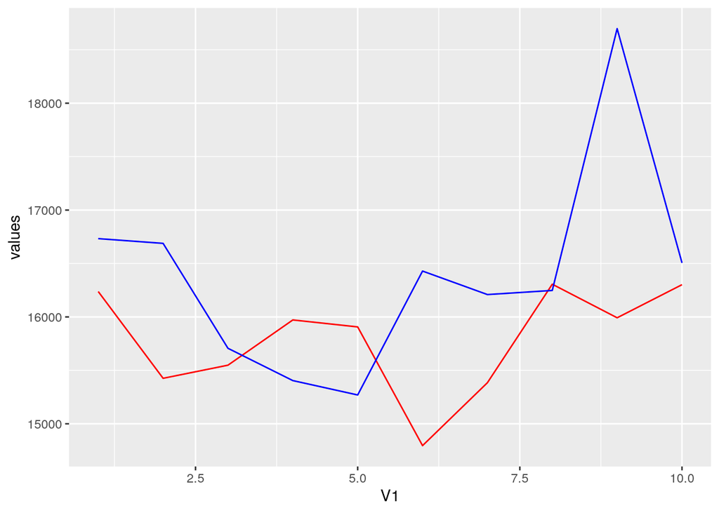

```r
library(ggplot2)
results <- cbind(seq(1, 10, 1), values, values2)
ggplot(as.data.frame(results), aes(x = V1)) +
    geom_line(aes(y = values), color = "red") +
    geom_line(aes(y = values2), color = "blue")
```

A to średnie z wyników testu RMSE:

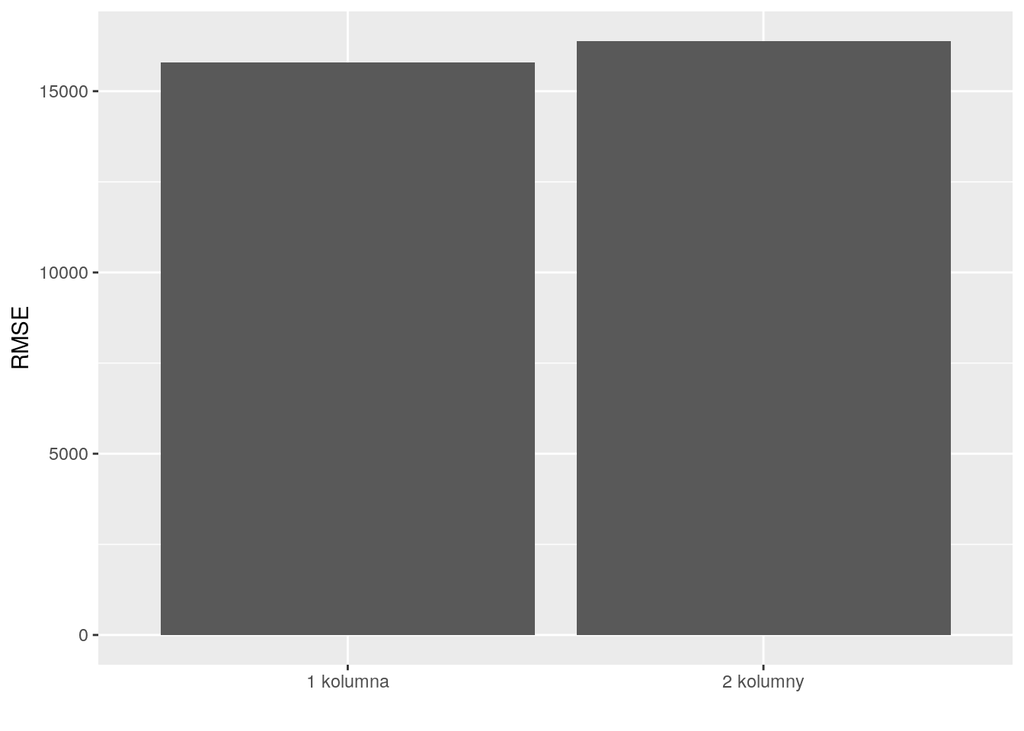

```r
results <- as.data.frame(results)
x <- c(mean(results$values), mean(results$values2))

ggplot(as.data.frame(x), aes(x = c("1 kolumna", "2 kolumny"), y = x)) +
    geom_bar(stat = "identity") +
    xlab("") +
    ylab("RMSE")
```